# Background and Context

AllLife Bank is a US bank that has a growing customer base. The majority of these customers are liability customers (depositors) with varying sizes of deposits. The number of customers who are also borrowers (asset customers) is quite small, and the bank is interested in expanding this base rapidly to bring in more loan business and in the process, earn more through the interest on loans. In particular, the management wants to explore ways of converting its liability customers to personal loan customers (while retaining them as depositors).

A campaign that the bank ran last year for liability customers showed a healthy conversion rate of over 9% success. This has encouraged the retail marketing department to devise campaigns with better target marketing to increase the success ratio.

# Objective

1. To predict whether a liability customer will buy a personal loan or not.
2. Which variables are most significant.
3. Which segment of customers should be targeted more.

# Variables to be analyzed

- ID: Customer ID
- Age: Customer’s age in completed years
- Experience: #years of professional experience
- Income: Annual income of the customer (in thousand dollars)
- ZIP Code: Home Address ZIP code.
- Family: the Family size of the customer
- CCAvg: Average spending on credit cards per month (in thousand dollars)
- Education: Education Level. 1: Undergrad; 2: Graduate;3: Advanced/Professional
- Mortgage: Value of house mortgage if any. (in thousand dollars)
- Personal_Loan: Did this customer accept the personal loan offered in the last campaign?
- Securities_Account: Does the customer have securities account with the bank?
- CD_Account: Does the customer have a certificate of deposit (CD) account with the bank?
- Online: Do customers use internet banking facilities?
- CreditCard: Does the customer use a credit card issued by any other Bank (excluding All life Bank)?

# Importing modules and packages

```python
#import the important packages
import warnings
warnings.filterwarnings('ignore')
import pandas as pd #library used for data manipulation and analysis
import numpy as np # library used for working with arrays.
import matplotlib.pyplot as plt # library for plots and visualisations
import seaborn as sns # library for visualisations
import random
from sklearn.model_selection import train_test_split
from sklearn.preprocessing import PolynomialFeatures
from sklearn import linear_model
from scipy.stats import pearsonr
%matplotlib inline

import scipy.stats as stats # this library contains a large number of probability distributions as well as a growing library of
```

```python
!pip install uszipcode
```

```python
from uszipcode import Zipcode, SearchEngine
```

# Reading and pre-processing the data

```python
data = pd.read_csv('Loan_Modelling.csv', index_col = 0) #reading the data
np.random.seed(1)
data.sample(n = 10) #random sample of 10 values
```

| ID | Age | Experience | Income | ZIPCode | Family | CCAvg | Education | Mortgage | Personal_Loan | Securities_Account | CD_Account | Online | CreditCard |
| --- | --- | --- | --- | --- | --- | --- | --- | --- | --- | --- | --- | --- | --- |
| 2765 | 31 | 5 | 84 | 91320 | 1 | 2.9 | 3 | 105 | 0 | 0 | 0 | 0 | 1 |
| 4768 | 35 | 9 | 45 | 90639 | 3 | 0.9 | 1 | 101 | 0 | 1 | 0 | 0 | 0 |
| 3815 | 34 | 9 | 35 | 94304 | 3 | 1.3 | 1 | 0 | 0 | 0 | 0 | 0 | 0 |
| 3500 | 49 | 23 | 114 | 94550 | 1 | 0.3 | 1 | 286 | 0 | 0 | 0 | 1 | 0 |
| 2736 | 36 | 12 | 70 | 92131 | 3 | 2.6 | 2 | 165 | 0 | 0 | 0 | 1 | 0 |
| 3923 | 31 | 4 | 20 | 95616 | 4 | 1.5 | 2 | 0 | 0 | 0 | 0 | 1 | 0 |
| 2702 | 50 | 26 | 55 | 94305 | 1 | 1.6 | 2 | 0 | 0 | 0 | 0 | 1 | 0 |
| 1180 | 36 | 11 | 98 | 90291 | 3 | 1.2 | 3 | 0 | 0 | 1 | 0 | 0 | 1 |
| 933 | 51 | 27 | 112 | 94720 | 3 | 1.8 | 2 | 0 | 0 | 1 | 1 | 1 | 1 |
| 793 | 41 | 16 | 98 | 93117 | 1 | 4.0 | 3 | 0 | 0 | 0 | 0 | 0 | 1 |

```python
data.shape  #the shape of the data
```

```
(5000, 13)
```

```python
data.info() #info of all the variables
```

```
<class 'pandas.core.frame.DataFrame'>
Int64Index: 5000 entries, 1 to 5000
Data columns (total 13 columns):
 #   Column              Non-Null Count  Dtype
---  ------              --------------  -----
 0   Age                 5000 non-null   int64
 1   Experience          5000 non-null   int64
 2   Income              5000 non-null   int64
 3   ZIPCode             5000 non-null   int64
 4   Family              5000 non-null   int64
 5   CCAvg               5000 non-null   float64
 6   Education           5000 non-null   int64
 7   Mortgage            5000 non-null   int64
 8   Personal_Loan       5000 non-null   int64
 9   Securities_Account  5000 non-null   int64
 10  CD_Account          5000 non-null   int64
 11  Online              5000 non-null   int64
 12  CreditCard          5000 non-null   int64
dtypes: float64(1), int64(12)
memory usage: 546.9 KB
```

Observation:

1. THere are a total of 5000 entris with 13 variables
2. Variables like Personal_loan, Securities_Account, CD_Account, Online, CreditCard need to be addressed as categorical variables.

```python
data.isnull().sum().sort_values(ascending=False) #sum of all the null values per variable
```

```
CreditCard            0
Online                0
CD_Account            0
Securities_Account    0
Personal_Loan         0
Mortgage              0
Education             0
CCAvg                 0
Family                0
ZIPCode               0
Income                0
Experience            0
Age                   0
dtype: int64
```

Observation:

1. No null values are observed within all the variables.

```python
data['Personal_Loan'] = data['Personal_Loan'].astype('category')
data['Securities_Account'] = data['Securities_Account'].astype('category')
data['CD_Account'] = data['CD_Account'].astype('category') #converting to categorical variables
data['Online'] = data['Online'].astype('category')
data['Family'] = data['Family'].astype('category')
data['Education'] = data['Education'].astype('category')
data['CreditCard'] = data['CreditCard'].astype('category')
```

```python
zip=data['ZIPCode'] #converting all the ZIp codes to major cities
zip=zip.astype(int)
zip=zip.astype(str)
major_city = []
for i in zip:
    search = SearchEngine()
    zipcode = search.by_zipcode(i).major_city
    major_city.append(zipcode)
```

```python
data = data.assign(Major_city=major_city) #adding the major_cities column to the main data set.
data.drop(['ZIPCode'],axis=1,inplace=True)
data['Major_city'] = data['Major_city'].astype('category')
```

```python
data.nunique(dropna = False) #unique values from each variable
```

```
Age                    45
Experience             47
Income                162
Family                  4
CCAvg                 108
Education               3
Mortgage              347
Personal_Loan           2
Securities_Account      2
CD_Account              2
Online                  2
CreditCard              2
Major_city            245
dtype: int64
```

```python
data.info() #checking the data info now
```

```
<class 'pandas.core.frame.DataFrame'>
Int64Index: 5000 entries, 1 to 5000
Data columns (total 13 columns):
 #   Column              Non-Null Count  Dtype
---  ------              --------------  -----
 0   Age                 5000 non-null   int64
 1   Experience          5000 non-null   int64
 2   Income              5000 non-null   int64
 3   Family              5000 non-null   category
 4   CCAvg               5000 non-null   float64
 5   Education           5000 non-null   category
 6   Mortgage            5000 non-null   int64
 7   Personal_Loan       5000 non-null   category
 8   Securities_Account  5000 non-null   category
 9   CD_Account          5000 non-null   category
 10  Online              5000 non-null   category
 11  CreditCard          5000 non-null   category
 12  Major_city          4966 non-null   category
dtypes: category(8), float64(1), int64(4)
memory usage: 291.0 KB
```

```python
data.isnull().sum().sort_values(ascending=False)
```

```
Major_city            34
CreditCard             0
Online                 0
CD_Account             0
Securities_Account     0
Personal_Loan          0
Mortgage               0
Education              0
CCAvg                  0
Family                 0
Income                 0
Experience             0
Age                    0
dtype: int64
```

Observation:

1. After converting the zip-codes to major cities, some of the major-city values are observed to be none, this variable will be taken as categorical variables, so none can be a type of category

```python
data['Major_city'] = data['Major_city'].astype(str).replace('nan', 'is_missing').astype('category') #converting the None type to a category
```

```python
num = data._get_numeric_data() #some values in the Experience column are negative, so converting the values to 0. Negative experience can't be measured, so converting them to 0 makes more sense, instead of dropping the values.
num[num < 0] = 0
```

```python
print(data.describe().T) #statistics of all the variables
```

```
             count       mean         std   min   25%   50%    75%    max
Age         5000.0  45.338400   11.463166  23.0  35.0  45.0   55.0   67.0
Experience  5000.0  20.119600   11.440484   0.0  10.0  20.0   30.0   43.0
Income      5000.0  73.774200   46.033729   8.0  39.0  64.0   98.0  224.0
CCAvg       5000.0   1.937938    1.747659   0.0   0.7   1.5    2.5   10.0
Mortgage    5000.0  56.498800  101.713802   0.0   0.0   0.0  101.0  635.0
```

Observation:

1. There are no negative values observed, data has been cleaned.
2. High variance in teh Income data, there is a big range in the income data.
3. The values in the Mortgage are observed towards the 75th percentile

```python
print(data.describe(include = 'category')) #categorical variables statistics
```

```
        Family  Education  Personal_Loan  Securities_Account  CD_Account  \
count     5000       5000           5000                5000        5000
unique       4          3              2                   2           2
top          1          1              0                   0           0
freq      1472       2096           4520                4478        4698

        Online  CreditCard   Major_city
count     5000        5000         5000
unique       2           2          245
top          1           0  Los Angeles
freq      2984        3530          375
```

Observation:

1. Family has 4 unique values, with 1 being the highest.
2. Education has the 3 unqiue valus with 1 being the highest.
3. Personal Loan, the most frequent is 0.
4. Secruities_acoount, CD_account, Online, CreditCard all have values of 2.
5. There are 245 unique Major Cities, if the variable isn't providing useful information, it may be dropped.

# EDA

```python
def histogram_boxplot(feature):
    """ Boxplot and histogram combined
    feature: 1-d feature array
    """
    figure, (ax_box2, ax_hist2, ax_hist3) = plt.subplots(
        nrows = 1, ncols=3,# Number of rows of the subplot grid= 2
        figsize  = (20,5)) # creating the 2 subplots
    figure.tight_layout(pad = 7)
    sns.boxplot(x = feature,ax=ax_box2, color = '#4B8BBE', orient = 'v') # boxplot will be created
    sns.distplot(feature, kde=True, ax=ax_hist2, color = '#a9a38f') # For histogram
    sns.distplot(feature, kde= True, ax=ax_hist3, hist = False) #Making an outline of the histogram
    ax_hist2.axvline(np.mean(feature), color='r', linestyle='--') # Add mean to the histogram
    ax_hist2.axvline(np.median(feature), color='black', linestyle='-') # Add median to the histogram
    ax_hist3.axvline(np.mean(feature), color = 'black', linestyle = '--') #Adding mean to second histogram
    ax_hist3.axvline(np.median(feature), color='black', linestyle='-') #Adding median to second histogram
```

## Observations on Age

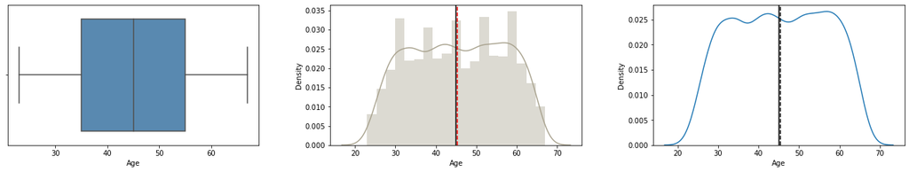

```python
histogram_boxplot(data.Age)
```

Observation:

1. There seems to be no outliers present
2. Data is evenly distributed to the right and left of the mean.

### Observations on Experience

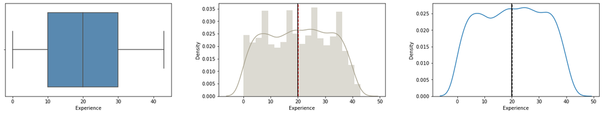

```python
histogram_boxplot(data['Experience'])
```

Observation:

1. Data is most eveenly distributed to the right and left of the mean.
2. Mean appears to be at 20.
3. No outliers visible.

### Observations on Income

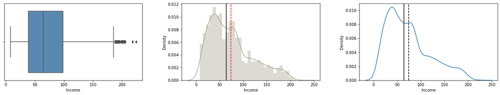

```python
histogram_boxplot(data['Income'])
```

Observation:

### Observations on CCAvg

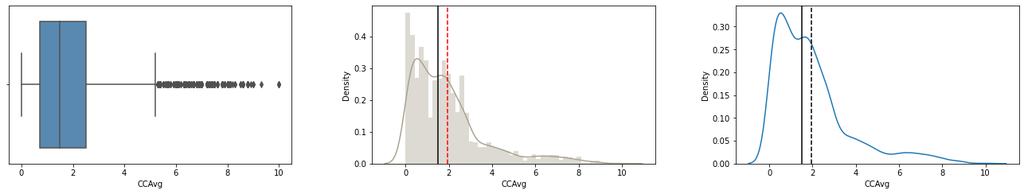

```python
histogram_boxplot(data['CCAvg'])
```

Observation:

### Observations on Mortgage

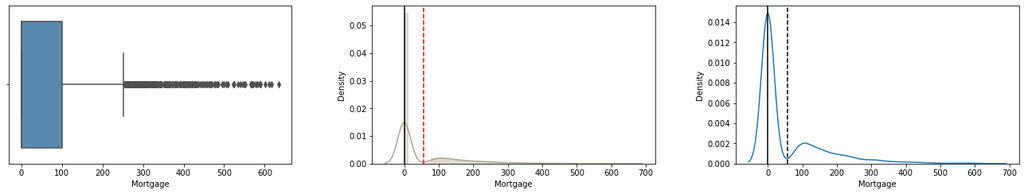

```python
histogram_boxplot(data['Mortgage'])
```

Observation:

1. Mostly rightly skewed data.
2. The min and the 25th percentile seems to be equal.
3. Lots of outliers visible

## Outlier treatments

```python
# Let's treat outliers by flooring and capping
def treat_outliers(df, col):
    """
    treats outliers in a variable
    col: str, name of the numerical variable
    df: dataframe
    col: name of the column
    """
    Q1 = df[col].quantile(0.25)  # 25th quantile
    Q3 = df[col].quantile(0.75)  # 75th quantile
    IQR = Q3 - Q1
    Lower_Whisker = Q1 - 1.5 * IQR
    Upper_Whisker = Q3 + 1.5 * IQR

    # all the values smaller than Lower_Whisker will be assigned the value of Lower_Whisker
    # all the values greater than Upper_Whisker will be assigned the value of Upper_Whisker
    df[col] = np.clip(df[col], Lower_Whisker, Upper_Whisker)

    return df


def treat_outliers_all(df, col_list):
    """
    treat outlier in all numerical variables
    col_list: list of numerical variables
    df: data frame
    """
    for c in col_list:
        df = treat_outliers(df, c)

    return df
```

```python
numeric_columns = data.select_dtypes(include=np.number).columns.tolist()#numberic columns
numerical_col = data.select_dtypes(include=np.number).columns.tolist()#converting numerical cols
data = treat_outliers_all(data, numerical_col) #treating outliers
```

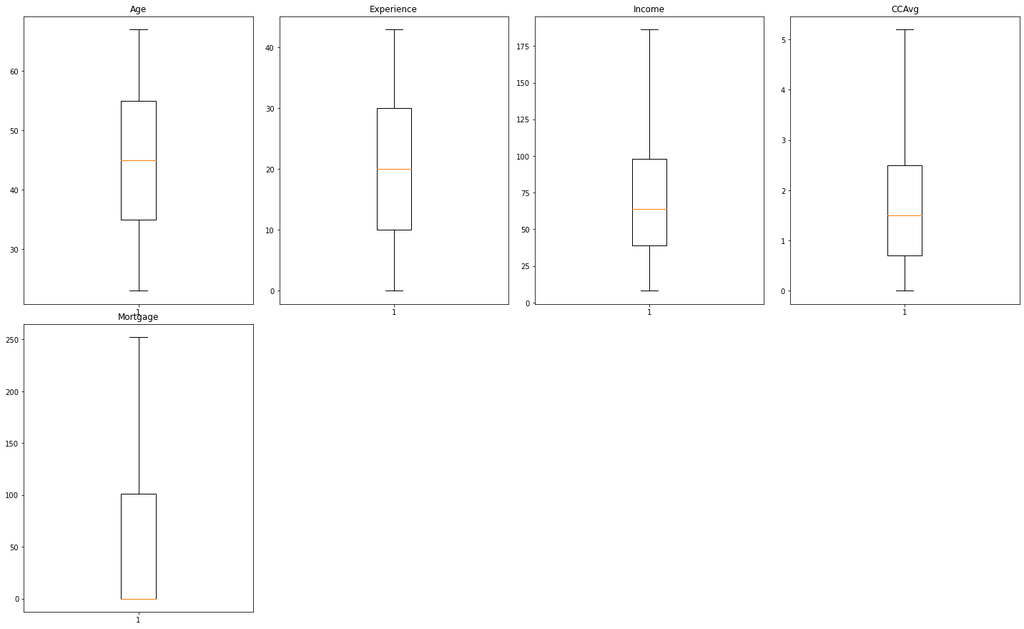

```python
plt.figure(figsize=(20, 30))

for i, variable in enumerate(numeric_columns): #boxplots subplots
    plt.subplot(5, 4, i + 1)
    plt.boxplot(data[variable], whis=1.5)
    plt.tight_layout()
    plt.title(variable)

plt.show()
```

Observation:

1. As it can be seen above, all outliers has been treated and no outliers remain.

## Categorical Variables

```python
def bar_perc(plot, feature):
    '''
    plot
    feature: 1-d categorical feature array
    '''
    total = len(feature) # length of the column
    for p in ax.patches:
        percentage = '{:.1f}%'.format(100 * p.get_height()/total) # percentage of each class of the category
        x = p.get_x() + p.get_width() / 2 - 0.05 # width of the plot
        y = p.get_y() + p.get_height()           # hieght of the plot
        ax.annotate(percentage, (x, y), size = 12) # annotate the percantage
```

### Observations on Family

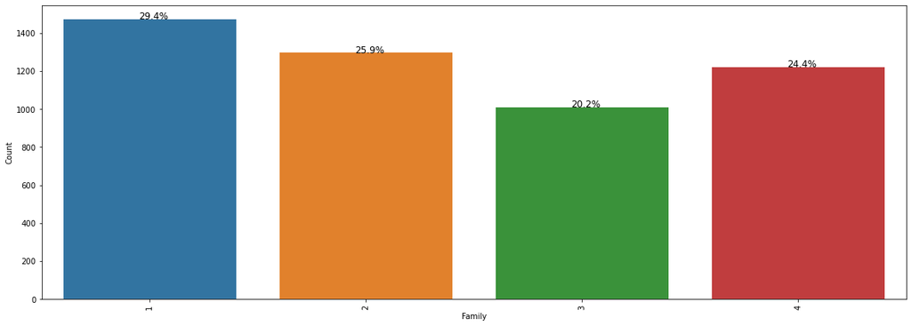

```python
plt.figure(figsize=(20,7))
ax = sns.countplot(data['Family']) #count plot for Name
plt.xlabel('Family')
plt.xticks(rotation=90)
plt.ylabel('Count')
bar_perc(ax,data['Family'])
```

Observations:

1. 1 Member households are most common
2. Least common is 3 member households at 20.2%

### Observations on Education

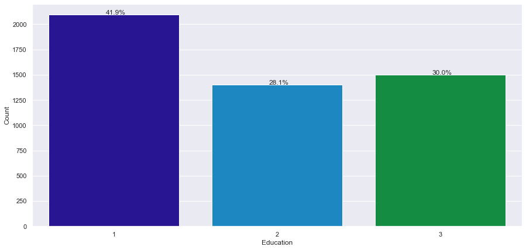

```python
plt.figure(figsize=(15,7))
ax = sns.countplot(data['Education']) #count plot for Location
plt.xlabel('Education')
plt.ylabel('Count')
bar_perc(ax,data['Education'])
```

Observation:

1. Undergraduate are most common with 41.9%
2. Least Common is Masters degree with 28.1%

### Observation on Personal Loan

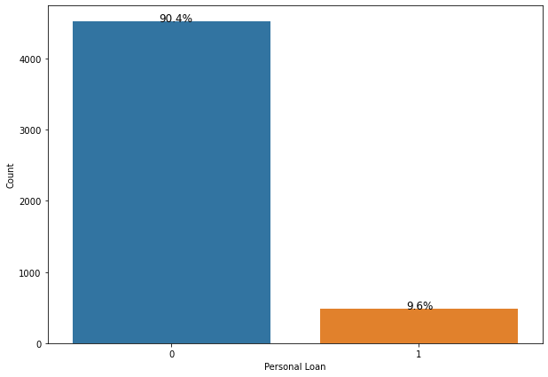

```python
plt.figure(figsize=(10,7))
ax = sns.countplot(data['Personal_Loan'])
plt.xlabel('Personal Loan')
plt.ylabel('Count')
bar_perc(ax,data['Personal_Loan'])
```

Observation:

1. Most observations 90.4% haven't taken a loan
2. 9.6% has only taken a loan

### Observation on Securities Account

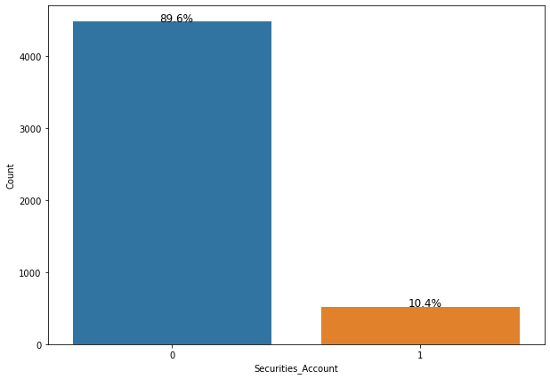

```python
plt.figure(figsize=(10,7))
ax = sns.countplot(data['Securities_Account'])
plt.xlabel('Securities_Account')
plt.ylabel('Count')
bar_perc(ax,data['Securities_Account'])
```

Observation:

1. Most clients do not have a securities account at almost 90%
2. 10% of the cleints have securities account

### Observation on CD_Account

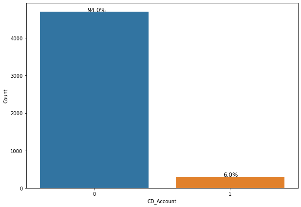

```python
plt.figure(figsize=(10,7))
ax = sns.countplot(data['CD_Account'])
plt.xlabel('CD_Account')
plt.ylabel('Count')
bar_perc(ax,data['CD_Account'])
```

Observation:

1. Most customers do not have a CD_account with 94%
2. 6% have CD_Account

### Observation on Online

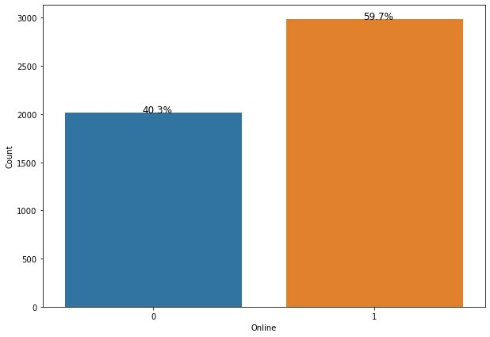

```python
plt.figure(figsize=(10,7))
ax = sns.countplot(data['Online'])
plt.xlabel('Online')
plt.ylabel('Count')
bar_perc(ax,data['Online'])
```

Observation:

1. 60% of customers use online interenet facilities provided by the bank
2. 40% do not use any interenet facilities.

### Observation on CreditCard

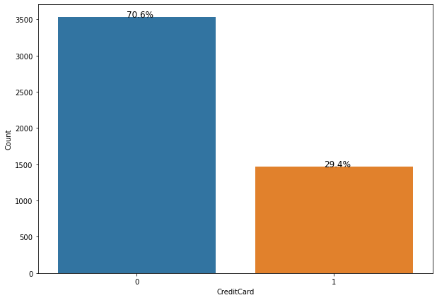

```python
plt.figure(figsize=(10,7))
ax = sns.countplot(data['CreditCard'])
plt.xlabel('CreditCard')
plt.ylabel('Count')
bar_perc(ax,data['CreditCard'])
```

Observation:

1. 70% of customers do not use credit cards
2. 30% of customers do use credit cards

### Observation on MajorCity

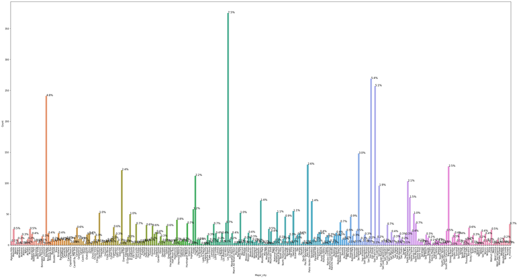

```python
plt.figure(figsize=(40,20))
ax = sns.countplot(data['Major_city'])
plt.xlabel('Major_city')
plt.xticks(rotation= 90)
plt.ylabel('Count')
bar_perc(ax,data['Major_city'])
```

Observation:

## Bivariate Analysis

```python
data.corr() #correlation of data
```

|  | Age | Experience | Income | CCAvg | Mortgage |
| --- | --- | --- | --- | --- | --- |
| Age | 1.000000 | 0.994198 | -0.054988 | -0.052032 | -0.012033 |
| Experience | 0.994198 | 1.000000 | -0.046429 | -0.050544 | -0.010807 |
| Income | -0.054988 | -0.046429 | 1.000000 | 0.637869 | 0.135018 |
| CCAvg | -0.052032 | -0.050544 | 0.637869 | 1.000000 | 0.068329 |
| Mortgage | -0.012033 | -0.010807 | 0.135018 | 0.068329 | 1.000000 |

```python
data.cov() #covariance of data
```

|  | Age | Experience | Income | CCAvg | Mortgage |
| --- | --- | --- | --- | --- | --- |
| Age | 131.404166 | 130.383204 | -28.759880 | -0.866176 | -11.448996 |
| Experience | 130.383204 | 130.884673 | -24.235388 | -0.839746 | -10.262119 |
| Income | -28.759880 | -24.235388 | 2081.742966 | 42.264531 | 511.343041 |
| CCAvg | -0.866176 | -0.839746 | 42.264531 | 2.108928 | 8.236490 |
| Mortgage | -11.448996 | -10.262119 | 511.343041 | 8.236490 | 6889.896601 |

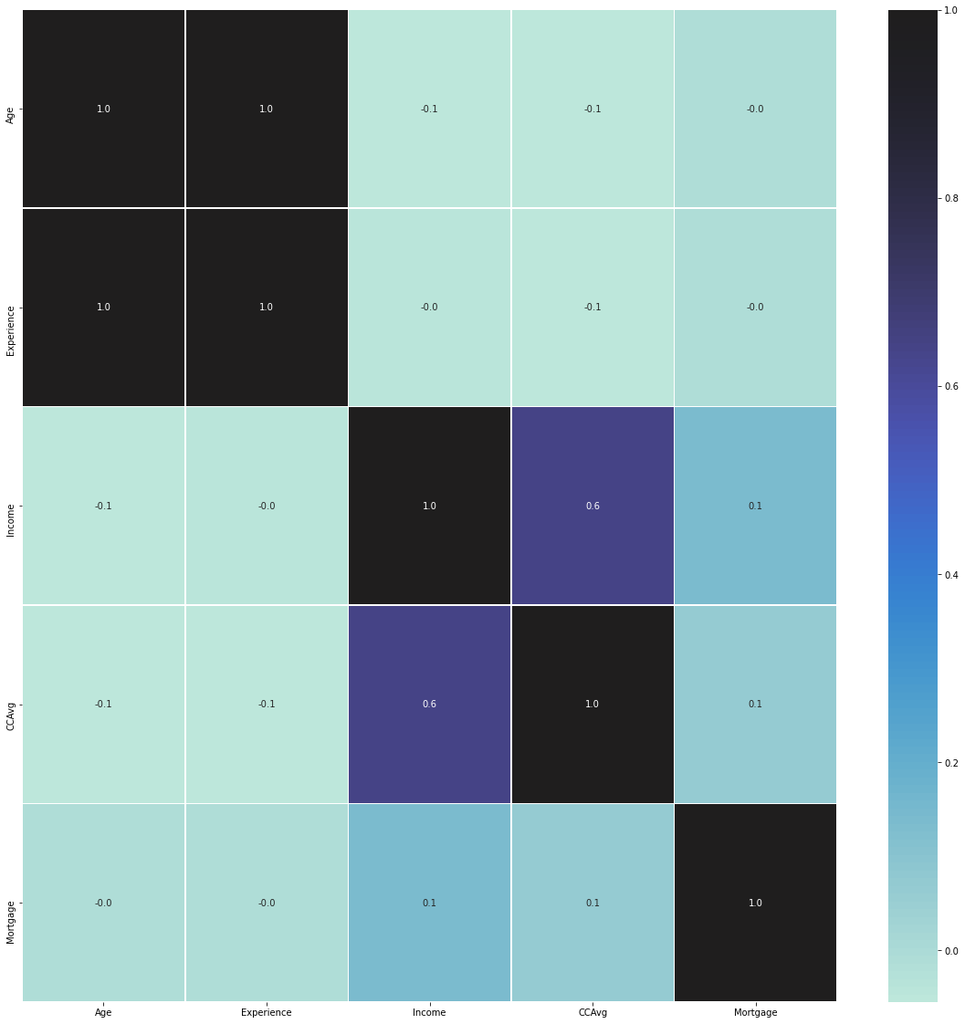

```python
plt.figure(figsize=(20,20))
sns.heatmap(data.corr(), annot=True, linewidths=.5, fmt= '.1f', center = 1 )  # heatmap
plt.show()
```

Observation:

1. Near perfect correlation between Age and Experience
2. Income and CCAvg have high correaltion between the variables.
3. All other variables have low correlation between each other

### Numerical Vs Categorical

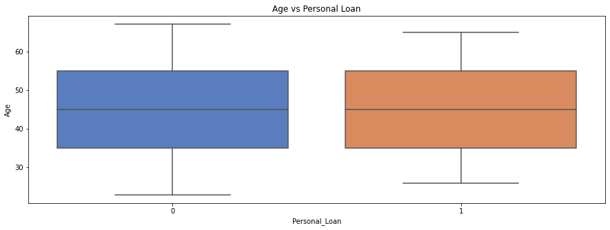

```python
plt.figure(figsize=(15,5))  # setting the figure size
plt.title('Age vs Personal Loan')
ax = sns.boxplot(x='Personal_Loan', y='Age', data=data, palette='muted')#barplot of location vs price
```

Observations:

1. Personal Loan appear to be equal in all age cateogries
2. Age does not appear to be a strong indicator of when clients take personal loan

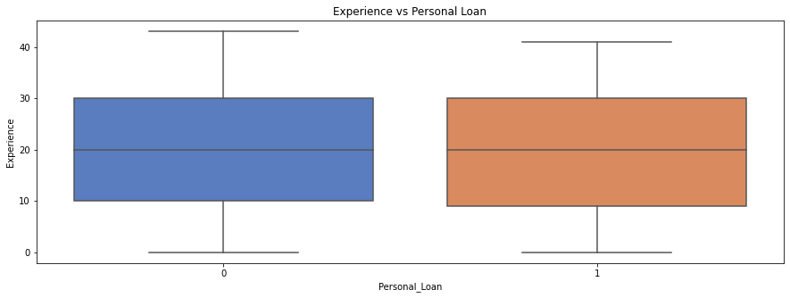

```python
plt.figure(figsize=(15,5))  # setting the figure size
plt.title('Experience vs Personal Loan')
ax = sns.boxplot(x='Personal_Loan', y='Experience', data=data, palette='muted')
```

Observations:

1. There does not appear to be much difference between personal loan and expereince

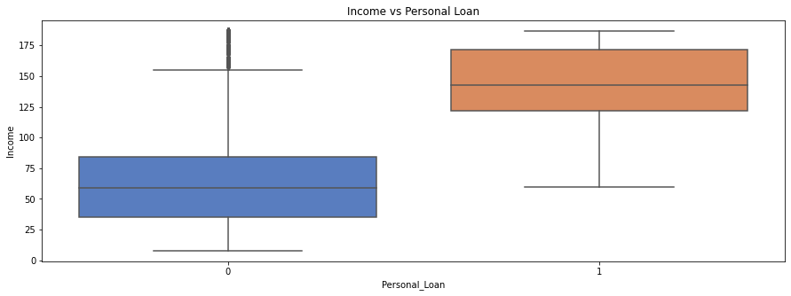

```python
plt.figure(figsize=(15,5))  # setting the figure size
plt.title('Income vs Personal Loan')
ax = sns.boxplot(x='Personal_Loan', y='Income', data=data, palette='muted')
```

Observation:

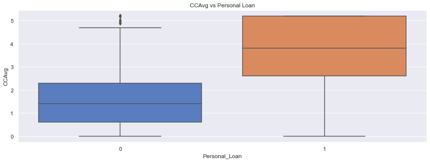

```python
plt.figure(figsize=(15,5))  # setting the figure size
plt.title('CCAvg vs Personal Loan')
ax = sns.boxplot(x='Personal_Loan', y='CCAvg', data=data, palette='muted')
```

Observation:

1. On average clinets who do not take personal loan have lower CCAvg, while clients who do take personal loan have higher CCAvg.
2. The 75th percentile of clients who take personal loan have higher CCAvg than clients who do not take personal loan

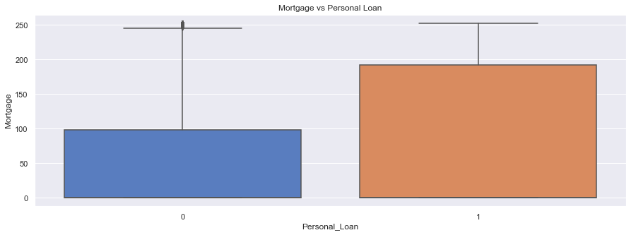

```python
plt.figure(figsize=(15,5))  # setting the figure size
plt.title('Mortgage vs Personal Loan')
ax = sns.boxplot(x='Personal_Loan', y='Mortgage', data=data, palette='muted')
```

Observation:

1. There appear to be some outliers in Mortgage with clients who do not take personal loan
2. There are more clients who take Personal Loan who have higher mortgage.

### Observation on Income, Family and Personal Loan

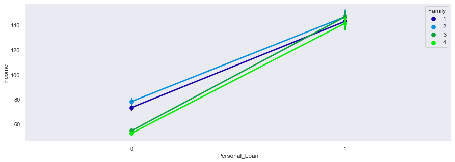

```python
plt.figure(figsize=(15,5))

sns.pointplot(x="Personal_Loan", y='Income', hue = 'Family',  data=data)
plt.show()
```

Observation:

1. Family with higher income take personal loans as compared to family wiht lower income.

### Observation on Education, Personal Loan and Income

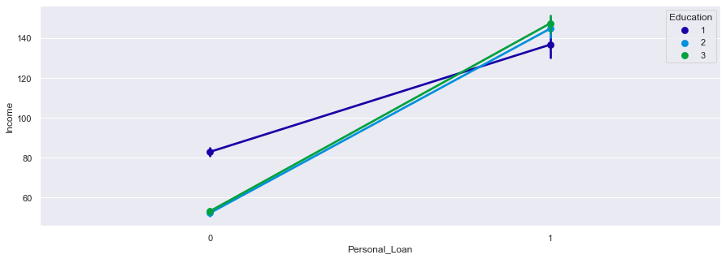

```python
plt.figure(figsize=(15,5))

sns.pointplot(x="Personal_Loan", y='Income', hue = 'Education',  data=data)
plt.show()
```

Observation:

1. Personal loan are opted by higher income clients regradeless of what education level they have.
2. Level 3 education level are more likely to take Personal loans as comared to level 2 and level 1 education clients

### Observation on Securities Account, Personal Loan and Income

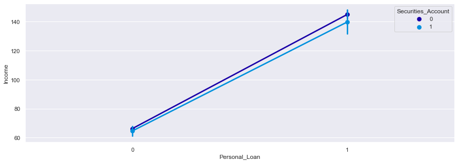

```python
plt.figure(figsize=(15,5))

sns.pointplot(x="Personal_Loan", y='Income', hue = 'Securities_Account',  data=data)
plt.show()
```

Observation:

1. Less Clients take personal loan with securities account.
2. Higher income clients are less likely to have a securities account and a personal loan

### Observation on CD_Account, Personal Loan and Income

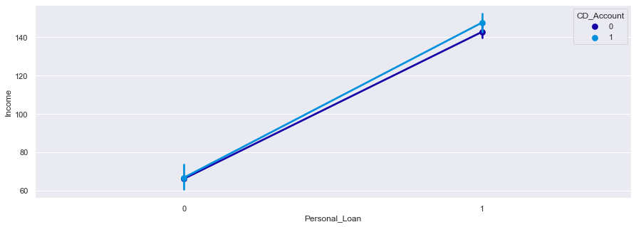

```python
plt.figure(figsize=(15,5))

sns.pointplot(x="Personal_Loan", y='Income', hue = 'CD_Account',  data=data)
plt.show()
```

Observation:

1. Clients with higher income do own a CD_Account when taking a personal Loan

### Observation on Online, Personal Loan and Income

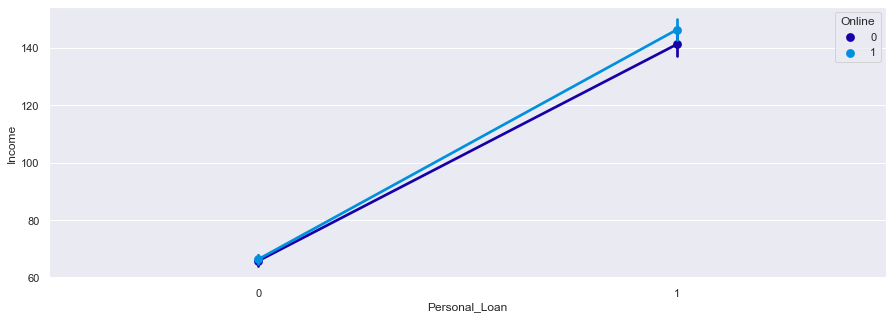

```python
plt.figure(figsize=(15,5))

sns.pointplot(x="Personal_Loan", y='Income', hue = 'Online',  data=data)
plt.show()
```

Observation:

1. Clients with higher income do own use the online faciltiies do take a personal Loan

### Observation on CreditCard, Personal Loan and Income

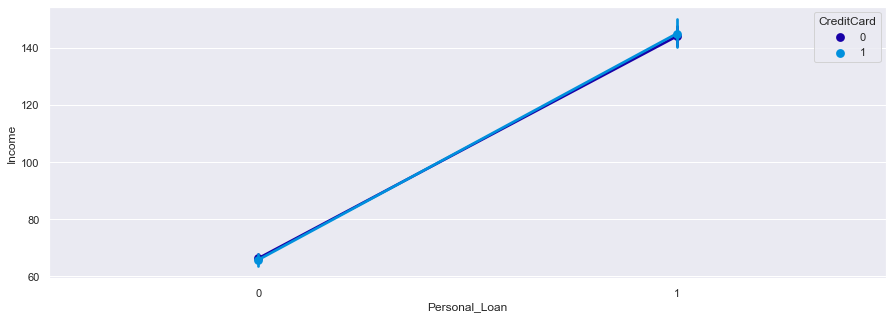

```python
plt.figure(figsize=(15,5))

sns.pointplot(x="Personal_Loan", y='Income', hue = 'CreditCard',  data=data)
plt.show()
```

Observation:

1. There isn't much different in clients with higher or lower income when it comes to owning a creditcard and taking personal loans

### Barplots for all non-categorical variables against Personal_Loan

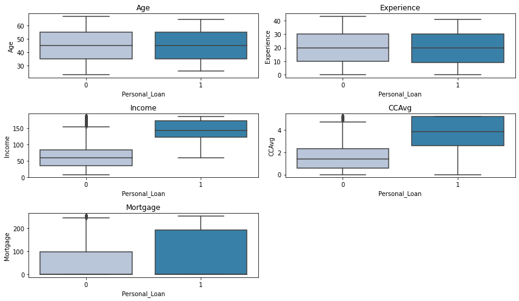

```python
cols = data[['Age','Experience','Income','CCAvg','Mortgage']].columns.tolist()
plt.figure(figsize=(12,7))

for i, variable in enumerate(cols):
                     plt.subplot(3,2,i+1)
                     sns.boxplot(data["Personal_Loan"],data[variable],palette="PuBu")
                     plt.tight_layout()
                     plt.title(variable)
plt.show()
```

Observation:

1. Income, CCAvg and Mortgage, all have impact on clients that take Personal Loan.
2. The variables Income, CCAvg and MOrtgage have higher values on average when a client decides to take a personal loan
3. Age and experience do not seem to have much impact on Personal Loan.

## Data Preparation for Modeling

```python
import scipy.stats as stats # this library contains a large number of probability distributions as well as a growing library of
import statsmodels.stats.api as sms
from statsmodels.stats.outliers_influence import variance_inflation_factor
import statsmodels.api as sm
from statsmodels.tools.tools import add_constant

# To build sklearn model
from sklearn.linear_model import LogisticRegression

# To get diferent metric scores
from sklearn import metrics
from sklearn.metrics import f1_score,accuracy_score, recall_score, precision_score, roc_auc_score, roc_curve, confusion_matrix, precision_recall_curve
```

```python
def split(*kwargs):
    '''
    Function to split data into X and Y then one hot encode the X variable.
    Returns training and test sets
    *kwargs : Variable to remove from the dataset before splitting into X and Y
    '''
    X = data.drop([*kwargs], axis=1)
    Y = data['Personal_Loan']

    X = pd.get_dummies(X,columns=["Family", 'Education', 'Securities_Account', 'CD_Account', 'Online', 'CreditCard'], drop_first=True)
    X = add_constant(X)

    #Splitting data in train and test sets
    X_train, X_test, y_train, y_test = train_test_split(X,Y, test_size=0.30, random_state = 1)
    return X_train,X_test, y_train, y_test
```

```python
X_train,X_test, y_train, y_test = split('Personal_Loan', 'Major_city')
print(X_test.head())
```

```
      const  Age  Experience  Income  CCAvg  Mortgage  Family_2  Family_3  \
ID
2765    1.0   31           5    84.0    2.9     105.0         0         0
4768    1.0   35           9    45.0    0.9     101.0         0         1
3815    1.0   34           9    35.0    1.3       0.0         0         1
3500    1.0   49          23   114.0    0.3     252.5         0         0
2736    1.0   36          12    70.0    2.6     165.0         0         1

      Family_4  Education_2  Education_3  Securities_Account_1  CD_Account_1  \
ID
2765         0            0            1                     0             0
4768         0            0            0                     1             0
3815         0            0            0                     0             0
3500         0            0            0                     0             0
2736         0            1            0                     0             0

      Online_1  CreditCard_1
ID
2765         0             1
4768         0             0
3815         0             0
3500         1             0
2736         1             0
```

Observation:

1. Major_city was excluded from any of the analysis as caused LinAlgError, as the correlation between the Major_city was highly correlated with other variables causing problems

```python
def get_metrics_score1(model,train,test,train_y,test_y,threshold=0.5,flag=True,roc=False):
    '''
    Function to calculate different metric scores of the model - Accuracy, Recall, Precision, and F1 score
    model: classifier to predict values of X
    train, test: Independent features
    train_y,test_y: Dependent variable
    threshold: thresold for classifiying the observation as 1
    flag: If the flag is set to True then only the print statements showing different will be displayed. The default value is set to True.
    roc: If the roc is set to True then only roc score will be displayed. The default value is set to False.
    '''
    # defining an empty list to store train and test results

    score_list=[]

    pred_train = (model.predict(train)>threshold)
    pred_test = (model.predict(test)>threshold)

    pred_train = np.round(pred_train)
    pred_test = np.round(pred_test)

    train_acc = accuracy_score(pred_train,train_y)
    test_acc = accuracy_score(pred_test,test_y)

    train_recall = recall_score(train_y,pred_train)
    test_recall = recall_score(test_y,pred_test)

    train_precision = precision_score(train_y,pred_train)
    test_precision = precision_score(test_y,pred_test)

    train_f1 = f1_score(train_y,pred_train)
    test_f1 = f1_score(test_y,pred_test)


    score_list.extend((train_acc,test_acc,train_recall,test_recall,train_precision,test_precision,train_f1,test_f1))


    if flag == True:
        print("Accuracy on training set : ",accuracy_score(pred_train,train_y))
        print("Accuracy on test set : ",accuracy_score(pred_test,test_y))
        print("Recall on training set : ",recall_score(train_y,pred_train))
        print("Recall on test set : ",recall_score(test_y,pred_test))
        print("Precision on training set : ",precision_score(train_y,pred_train))
        print("Precision on test set : ",precision_score(test_y,pred_test))
        print("F1 on training set : ",f1_score(train_y,pred_train))
        print("F1 on test set : ",f1_score(test_y,pred_test))

    if roc == True:
        print("ROC-AUC Score on training set : ",roc_auc_score(train_y,pred_train))
        print("ROC-AUC Score on test set : ",roc_auc_score(test_y,pred_test))

    return score_list # returning the list with train and test scores
```

```python
def get_metrics_score2(model,train,test,train_y,test_y,flag=True,roc=False):
    '''
    Function to calculate different metric scores of the model - Accuracy, Recall, Precision, and F1 score
    model: classifier to predict values of X
    train, test: Independent features
    train_y,test_y: Dependent variable
    flag: If the flag is set to True then only the print statements shwoing different will be displayed. The default value is set to True.
    roc: If the roc is set to True then only roc score will be displayed. The default value is set to False.
    '''
    # defining an empty list to store train and test results

    score_list=[]

    pred_train = model.predict(train)
    pred_test = model.predict(test)

    train_acc = accuracy_score(pred_train,train_y)
    test_acc = accuracy_score(pred_test,test_y)

    train_recall = recall_score(train_y,pred_train)
    test_recall = recall_score(test_y,pred_test)

    train_precision = precision_score(train_y,pred_train)
    test_precision = precision_score(test_y,pred_test)

    train_f1 = f1_score(train_y,pred_train)
    test_f1 = f1_score(test_y,pred_test)


    score_list.extend((train_acc,test_acc,train_recall,test_recall,train_precision,test_precision,train_f1,test_f1))

     # If the flag is set to True then only the following print statements will be dispayed. The default value is set to True.
    if flag == True:
        print("Accuracy on training set : ",accuracy_score(pred_train,train_y))
        print("Accuracy on test set : ",accuracy_score(pred_test,test_y))
        print("Recall on training set : ",recall_score(train_y,pred_train))
        print("Recall on test set : ",recall_score(test_y,pred_test))
        print("Precision on training set : ",precision_score(train_y,pred_train))
        print("Precision on test set : ",precision_score(test_y,pred_test))
        print("F1 on training set : ",f1_score(train_y,pred_train))
        print("F1 on test set : ",f1_score(test_y,pred_test))

    if roc == True:
        print("ROC-AUC Score on training set : ",roc_auc_score(train_y,pred_train))
        print("ROC-AUC Score on test set : ",roc_auc_score(test_y,pred_test))

    return score_list # returning the list with train and test scores
```

```python
def make_confusion_matrix(model,test_X,y_actual,labels=[1, 0]):
    '''
    model : classifier to predict values of X
    test_X: test set
    y_actual : ground truth

    '''
    y_predict = model.predict(test_X)
    cm=metrics.confusion_matrix( y_actual, y_predict, labels=[1,0])
    df_cm = pd.DataFrame(cm, index = [i for i in ["Actual - >50K","Actual - <=50K"]],
                  columns = [i for i in ['Predicted - >50K','Predicted - <=50k']])
    group_counts = ["{0:0.0f}".format(value) for value in
                cm.flatten()]
    group_percentages = ["{0:.2%}".format(value) for value in
                         cm.flatten()/np.sum(cm)]
    labels = [f"{v1}\n{v2}" for v1, v2 in
              zip(group_counts,group_percentages)]
    labels = np.asarray(labels).reshape(2,2)
    plt.figure(figsize = (10,7))
    sns.heatmap(df_cm, annot=labels,fmt='')
    plt.ylabel('True label')
    plt.xlabel('Predicted label')
```

```python
lr = LogisticRegression(solver='newton-cg',random_state=1,fit_intercept=False)
model  = lr.fit(X_train,y_train)

# Let's check model performances for this model
scores_LR = get_metrics_score2(model,X_train,X_test,y_train,y_test)
```

```
Accuracy on training set :  0.964
Accuracy on test set :  0.9546666666666667
Recall on training set :  0.7099697885196374
Recall on test set :  0.6174496644295302
Precision on training set :  0.8867924528301887
Precision on test set :  0.8932038834951457
F1 on training set :  0.7885906040268457
F1 on test set :  0.7301587301587301
```

```python
logit = sm.Logit(y_train, X_train)
lg = logit.fit(warn_convergence =False)

# Let's check model performances for this model
scores_LR = get_metrics_score1(lg,X_train,X_test,y_train,y_test)
```

```
Optimization terminated successfully.
         Current function value: 0.098908
         Iterations 10
Accuracy on training set :  0.9665714285714285
Accuracy on test set :  0.9613333333333334
Recall on training set :  0.7371601208459214
Recall on test set :  0.6644295302013423
Precision on training set :  0.8905109489051095
Precision on test set :  0.9252336448598131
F1 on training set :  0.8066115702479338
F1 on test set :  0.7734375000000001
```

```python
lg.summary()
```

Logit Regression Results

| Dep. Variable: | Personal_Loan | No. Observations: | 3500 |
| --- | --- | --- | --- |
| Model: | Logit | Df Residuals: | 3485 |
| Method: | MLE | Df Model: | 14 |
| Date: | Fri, 18 Jun 2021 | Pseudo R-squ.: | 0.6840 |
| Time: | 02:16:39 | Log-Likelihood: | -346.18 |
| converged: | True | LL-Null: | -1095.5 |
| Covariance Type: | nonrobust | LLR p-value: | 9.650e-312 |

|  | coef | std err | z | P>\|z\| | [0.025 | 0.975] |
| --- | --- | --- | --- | --- | --- | --- |
| const | -14.4607 | 2.312 | -6.254 | 0.000 | -18.992 | -9.929 |
| Age | -0.0162 | 0.083 | -0.194 | 0.846 | -0.180 | 0.147 |
| Experience | 0.0245 | 0.083 | 0.294 | 0.769 | -0.139 | 0.188 |
| Income | 0.0662 | 0.004 | 15.694 | 0.000 | 0.058 | 0.074 |
| CCAvg | 0.5316 | 0.080 | 6.645 | 0.000 | 0.375 | 0.688 |
| Mortgage | 0.0013 | 0.001 | 1.296 | 0.195 | -0.001 | 0.003 |
| Family_2 | 0.0655 | 0.296 | 0.221 | 0.825 | -0.515 | 0.646 |
| Family_3 | 2.7453 | 0.337 | 8.152 | 0.000 | 2.085 | 3.405 |
| Family_4 | 1.7806 | 0.325 | 5.481 | 0.000 | 1.144 | 2.417 |
| Education_2 | 4.2435 | 0.364 | 11.648 | 0.000 | 3.529 | 4.958 |
| Education_3 | 4.5111 | 0.367 | 12.308 | 0.000 | 3.793 | 5.229 |
| Securities_Account_1 | -1.0191 | 0.423 | -2.407 | 0.016 | -1.849 | -0.189 |
| CD_Account_1 | 3.6459 | 0.458 | 7.964 | 0.000 | 2.749 | 4.543 |
| Online_1 | -0.5915 | 0.214 | -2.759 | 0.006 | -1.012 | -0.171 |
| CreditCard_1 | -0.9789 | 0.280 | -3.498 | 0.000 | -1.527 | -0.430 |

Possibly complete quasi-separation: A fraction 0.19 of observations can be  
perfectly predicted. This might indicate that there is complete  
quasi-separation. In this case some parameters will not be identified.

But first we will have to remove multicollinearity from the data to get reliable coefficients and p-values.

1. There are different ways of detecting (or testing) multi-collinearity, one such way is the Variation Inflation Factor.
2. Additional Information on VIF Variance Inflation factor: Variance inflation factors measure the inflation in the variances of the regression coefficients estimates due to collinearities that exist among the predictors. It is a measure of how much the variance of the estimated regression coefficient βk is “inflated”by the existence of correlation among the predictor variables in the model.
3. General Rule of thumb: If VIF is 1 then there is no correlation among the kth predictor and the remaining predictor variables, and hence the variance of β̂k is not inflated at all. Whereas if VIF exceeds 5, we say there is moderate VIF and if it is 10 or exceeding 10, it shows signs of high multi-collinearity. But the purpose of the analysis should dictate which threshold to use

### Multicollinearity

```python
# changing datatype of colums to numeric for checking vif
X_train_num = X_train.astype(float).copy()
```

```python
vif_series1 = pd.Series([variance_inflation_factor(X_train_num.values,i) for i in range(X_train_num.shape[1])],index=X_train_num.columns, dtype = float)
print('Series before feature selection: \n\n{}\n'.format(vif_series1))
```

```
Series before feature selection:

const                   466.511039
Age                      95.850764
Experience               95.756287
Income                    1.831372
CCAvg                     1.707041
Mortgage                  1.020406
Family_2                  1.401950
Family_3                  1.384443
Family_4                  1.426069
Education_2               1.301434
Education_3               1.340159
Securities_Account_1      1.147680
CD_Account_1              1.363271
Online_1                  1.040982
CreditCard_1              1.111249
dtype: float64
```

Observation:

1. The high correlation between these variables has been highlighted in the VIF values as well.
2. Only Age and Experience show high multicollinearity

```python
X_train_num1 = X_train_num.drop('Age',axis=1)
vif_series2 = pd.Series([variance_inflation_factor(X_train_num1.values,i) for i in range(X_train_num1.shape[1])],index=X_train_num1.columns)
print('Series before feature selection: \n\n{}\n'.format(vif_series2))
```

```
Series before feature selection:

const                   15.205511
Experience               1.012893
Income                   1.825870
CCAvg                    1.701098
Mortgage                 1.020357
Family_2                 1.401880
Family_3                 1.380378
Family_4                 1.426022
Education_2              1.288092
Education_3              1.257142
Securities_Account_1     1.147226
CD_Account_1             1.362293
Online_1                 1.040816
CreditCard_1             1.111230
dtype: float64
```

Observation:

1. Dropping Age has reduced the high VIF values in Experience.

#### Let's create a model with all the features except Age

```python
X_train.drop(['Age'],axis=1,inplace=True)
X_test.drop(['Age'],axis=1,inplace=True)
```

```python
logit1 = sm.Logit(y_train, X_train.astype(float))
lg1 = logit1.fit(warn_convergence =False)

# Let's check model performances for this model
scores_LR = get_metrics_score1(lg1,X_train,X_test,y_train,y_test)
```

```
Optimization terminated successfully.
         Current function value: 0.098913
         Iterations 10
Accuracy on training set :  0.9662857142857143
Accuracy on test set :  0.9613333333333334
Recall on training set :  0.7311178247734139
Recall on test set :  0.6644295302013423
Precision on training set :  0.8929889298892989
Precision on test set :  0.9252336448598131
F1 on training set :  0.8039867109634551
F1 on test set :  0.7734375000000001
```

### Droping Experience

```python
X_train2,X_test2,y_train,y_test = split('Personal_Loan','Experience')
```

```python
X_train2.drop(['Major_city'],axis=1,inplace=True)
X_test2.drop(['Major_city'],axis=1,inplace=True)
```

```python
X_train_num3 = X_train2.astype(float).copy()
vif_series4 = pd.Series([variance_inflation_factor(X_train_num3.values,i) for i in range(X_train_num3.shape[1])],index=X_train_num3.columns)
print('Series before feature selection: \n\n{}\n'.format(vif_series4))
```

```
Series before feature selection:

const                   28.464443
Age                      1.013893
Income                   1.826586
CCAvg                    1.700369
Mortgage                 1.020371
Family_2                 1.401877
Family_3                 1.380454
Family_4                 1.425860
Education_2              1.287354
Education_3              1.257770
Securities_Account_1     1.147170
CD_Account_1             1.362048
Online_1                 1.040829
CreditCard_1             1.111222
dtype: float64
```

```python
logit3 = sm.Logit(y_train, X_train2.astype(float))
lg3 = logit3.fit(warn_convergence =False)

# Let's check model performances for this model
scores_LR = get_metrics_score1(lg3,X_train2,X_test2,y_train,y_test)
```

```
Optimization terminated successfully.
         Current function value: 0.098920
         Iterations 10
Accuracy on training set :  0.9665714285714285
Accuracy on test set :  0.9613333333333334
Recall on training set :  0.7311178247734139
Recall on test set :  0.6644295302013423
Precision on training set :  0.8962962962962963
Precision on test set :  0.9252336448598131
F1 on training set :  0.805324459234609
F1 on test set :  0.7734375000000001
```

Observation:

#### Summary of final model

```python
lg3.summary()
```

Logit Regression Results

| Dep. Variable: | Personal_Loan | No. Observations: | 3500 |
| --- | --- | --- | --- |
| Model: | Logit | Df Residuals: | 3486 |
| Method: | MLE | Df Model: | 13 |
| Date: | Fri, 18 Jun 2021 | Pseudo R-squ.: | 0.6839 |
| Time: | 02:18:24 | Log-Likelihood: | -346.22 |
| converged: | True | LL-Null: | -1095.5 |
| Covariance Type: | nonrobust | LLR p-value: | 0.000 |

|  | coef | std err | z | P>\|z\| | [0.025 | 0.975] |
| --- | --- | --- | --- | --- | --- | --- |
| const | -15.0822 | 0.945 | -15.959 | 0.000 | -16.935 | -13.230 |
| Age | 0.0082 | 0.009 | 0.923 | 0.356 | -0.009 | 0.026 |
| Income | 0.0663 | 0.004 | 15.802 | 0.000 | 0.058 | 0.075 |
| CCAvg | 0.5307 | 0.080 | 6.647 | 0.000 | 0.374 | 0.687 |
| Mortgage | 0.0013 | 0.001 | 1.288 | 0.198 | -0.001 | 0.003 |
| Family_2 | 0.0655 | 0.296 | 0.221 | 0.825 | -0.515 | 0.647 |
| Family_3 | 2.7451 | 0.337 | 8.150 | 0.000 | 2.085 | 3.405 |
| Family_4 | 1.7812 | 0.325 | 5.482 | 0.000 | 1.144 | 2.418 |
| Education_2 | 4.2395 | 0.364 | 11.642 | 0.000 | 3.526 | 4.953 |
| Education_3 | 4.4977 | 0.364 | 12.370 | 0.000 | 3.785 | 5.210 |
| Securities_Account_1 | -1.0168 | 0.424 | -2.399 | 0.016 | -1.848 | -0.186 |
| CD_Account_1 | 3.6483 | 0.458 | 7.967 | 0.000 | 2.751 | 4.546 |
| Online_1 | -0.5905 | 0.214 | -2.756 | 0.006 | -1.010 | -0.171 |
| CreditCard_1 | -0.9776 | 0.280 | -3.495 | 0.000 | -1.526 | -0.429 |

Possibly complete quasi-separation: A fraction 0.19 of observations can be  
perfectly predicted. This might indicate that there is complete  
quasi-separation. In this case some parameters will not be identified.

```python
X_train4 = X_train2.drop(['Age','Mortgage'], axis = 1)
X_test4 = X_test2.drop(['Age', 'Mortgage'], axis = 1)

logit4 = sm.Logit(y_train, X_train4.astype(float))
lg4 = logit4.fit(warn_convergence =False)

print(lg4.summary())
```

```
Optimization terminated successfully.
         Current function value: 0.099258
         Iterations 10
                           Logit Regression Results
==============================================================================
Dep. Variable:          Personal_Loan   No. Observations:                 3500
Model:                          Logit   Df Residuals:                     3488
Method:                           MLE   Df Model:                           11
Date:                Fri, 18 Jun 2021   Pseudo R-squ.:                  0.6829
Time:                        02:24:37   Log-Likelihood:                -347.40
converged:                       True   LL-Null:                       -1095.5
Covariance Type:            nonrobust   LLR p-value:                     0.000
========================================================================================
                           coef    std err          z      P>|z|      [0.025      0.975]
----------------------------------------------------------------------------------------
const                  -14.6094      0.817    -17.882      0.000     -16.211     -13.008
Income                   0.0664      0.004     15.869      0.000       0.058       0.075
CCAvg                    0.5182      0.079      6.531      0.000       0.363       0.674
Family_2                 0.0830      0.296      0.280      0.779      -0.497       0.663
Family_3                 2.7636      0.337      8.193      0.000       2.102       3.425
Family_4                 1.7845      0.325      5.483      0.000       1.147       2.422
Education_2              4.2119      0.363     11.613      0.000       3.501       4.923
Education_3              4.4714      0.362     12.359      0.000       3.762       5.180
Securities_Account_1    -1.0098      0.425     -2.375      0.018      -1.843      -0.176
CD_Account_1             3.6761      0.458      8.023      0.000       2.778       4.574
Online_1                -0.5891      0.214     -2.757      0.006      -1.008      -0.170
CreditCard_1            -0.9725      0.278     -3.497      0.000      -1.518      -0.427
========================================================================================

Possibly complete quasi-separation: A fraction 0.19 of observations can be
perfectly predicted. This might indicate that there is complete
quasi-separation. In this case some parameters will not be identified.
```

Observation:

1. Mortgage and Age that had high P values have been dropped.
2. Only high P-value is Family_2 which can be ingnored as not all the categorical values of Family are high.

#### Metrics of final model 'lg4'

```python
scores_LR = get_metrics_score1(lg4,X_train4,X_test4,y_train,y_test)
```

```
Accuracy on training set :  0.9691428571428572
Accuracy on test set :  0.9586666666666667
Recall on training set :  0.7371601208459214
Recall on test set :  0.6442953020134228
Precision on training set :  0.9207547169811321
Precision on test set :  0.9142857142857143
F1 on training set :  0.8187919463087249
F1 on test set :  0.7559055118110237
```

#### ROC-AUC

- ROC-AUC on training set

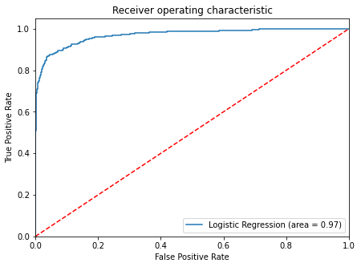

```python
logit_roc_auc_train = roc_auc_score(y_train, lg4.predict(X_train4))
fpr, tpr, thresholds = roc_curve(y_train, lg4.predict(X_train4))
plt.figure(figsize=(7,5))
plt.plot(fpr, tpr, label='Logistic Regression (area = %0.2f)' % logit_roc_auc_train)
plt.plot([0, 1], [0, 1],'r--')
plt.xlim([0.0, 1.0])
plt.ylim([0.0, 1.05])
plt.xlabel('False Positive Rate')
plt.ylabel('True Positive Rate')
plt.title('Receiver operating characteristic')
plt.legend(loc="lower right")
plt.show()
```

- ROC-AUC on test set

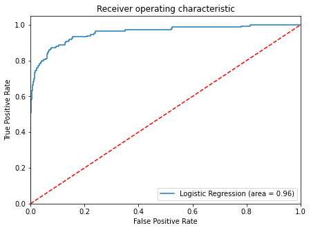

```python
logit_roc_auc_test = roc_auc_score(y_test, lg4.predict(X_test4)) #roc_auc test
fpr, tpr, thresholds = roc_curve(y_test, lg4.predict(X_test4))
plt.figure(figsize=(7,5))
plt.plot(fpr, tpr, label='Logistic Regression (area = %0.2f)' % logit_roc_auc_test)
plt.plot([0, 1], [0, 1],'r--')
plt.xlim([0.0, 1.0])
plt.ylim([0.0, 1.05])
plt.xlabel('False Positive Rate')
plt.ylabel('True Positive Rate')
plt.title('Receiver operating characteristic')
plt.legend(loc="lower right")
plt.show()
```

- Logistic Regression model is giving a generalized performance on training and test set.

### Converting coefficients to odds

- The coefficients of the logistic regression model are in terms of log(odd), to find the odds we have to take the exponential of the coefficients.
- Therefore, **odds = exp(b)**
- The percentage change in odds is given as **odds = (exp(b) - 1) * 100**
- Odds from coefficients

```python
odds = np.exp(lg4.params) # converting coefficients to odds
pd.set_option('display.max_columns',None)  # removing limit from number of columns to display
pd.DataFrame(odds, X_train4.columns, columns=['odds']).T # adding the odds to a dataframe
```

|  | const | Income | CCAvg | Family_2 | Family_3 | Family_4 | Education_2 | Education_3 | Securities_Account_1 | CD_Account_1 | Online_1 | CreditCard_1 |
| --- | --- | --- | --- | --- | --- | --- | --- | --- | --- | --- | --- | --- |
| odds | 4.520806e-07 | 1.068674 | 1.678945 | 1.086525 | 15.856514 | 5.956709 | 67.485613 | 87.47987 | 0.364301 | 39.491291 | 0.554852 | 0.378134 |

- Percentage change in odds

```python
perc_change_odds = (np.exp(lg4.params)-1)*100 # finding the percentage change
pd.set_option('display.max_columns',None) # removing limit from number of columns to display
pd.DataFrame(perc_change_odds, X_train4.columns, columns=['change_odds%']).T # adding the change_odds% to a dataframe
```

|  | const | Income | CCAvg | Family_2 | Family_3 | Family_4 | Education_2 | Education_3 | Securities_Account_1 | CD_Account_1 | Online_1 | CreditCard_1 |
| --- | --- | --- | --- | --- | --- | --- | --- | --- | --- | --- | --- | --- |
| change_odds% | -99.999955 | 6.867374 | 67.894538 | 8.652495 | 1485.651446 | 495.670882 | 6648.561295 | 8647.986976 | -63.569905 | 3849.129081 | -44.514791 | -62.186637 |

Coefficent Interpertations:

1. Having all other variables constant, 1 unit change in Income will increase the chances of taking a loan.
2. CCAvg, Family size, Education, 1 unit change will bring about positive change and increase chances of taking a loan.
3. HAving a securities account will decrease the changes of taking a loan by 63%.
4. Having an online account also decreases the chances of taking a loan by 44.5%.
5. Owning a credit card also decreases the chance of taking a loan by 62%.

```python
# Optimal threshold as per AUC-ROC curve
# The optimal cut off would be where tpr is high and fpr is low
fpr, tpr, thresholds = metrics.roc_curve(y_test, lg4.predict(X_test4))

optimal_idx = np.argmax(tpr - fpr)
optimal_threshold_auc_roc = thresholds[optimal_idx]
print(optimal_threshold_auc_roc)
```

```
0.0976608563542546
```

```python
scores_LR = get_metrics_score1(lg4,X_train4,X_test4,y_train,y_test,threshold=optimal_threshold_auc_roc,roc=True)
```

```
Accuracy on training set :  0.9165714285714286
Accuracy on test set :  0.918
Recall on training set :  0.8972809667673716
Recall on test set :  0.8657718120805369
Precision on training set :  0.5351351351351351
Precision on test set :  0.5560344827586207
F1 on training set :  0.6704288939051918
F1 on test set :  0.6771653543307086
ROC-AUC Score on training set :  0.9079336357976966
ROC-AUC Score on test set :  0.8947659948633624
```

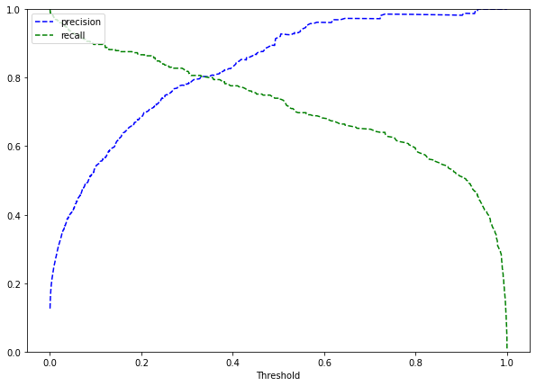

```python
y_scores=lg4.predict(X_train4)
prec, rec, tre = precision_recall_curve(y_train, y_scores,)

def plot_prec_recall_vs_tresh(precisions, recalls, thresholds):
    plt.plot(thresholds, precisions[:-1], 'b--', label='precision')
    plt.plot(thresholds, recalls[:-1], 'g--', label = 'recall')
    plt.xlabel('Threshold')
    plt.legend(loc='upper left')
    plt.ylim([0,1])
plt.figure(figsize=(10,7))
plot_prec_recall_vs_tresh(prec, rec, tre)
plt.show()
```

```python
optimal_threshold_curve = 0.38

scores_LR = get_metrics_score1(lg4,X_train4,X_test4,y_train,y_test,threshold=optimal_threshold_curve,roc=True)
```

```
Accuracy on training set :  0.9637142857142857
Accuracy on test set :  0.9573333333333334
Recall on training set :  0.7885196374622356
Recall on test set :  0.7114093959731543
Precision on training set :  0.8207547169811321
Precision on test set :  0.8346456692913385
F1 on training set :  0.8043143297380587
F1 on test set :  0.7681159420289855
ROC-AUC Score on training set :  0.8852664454272365
ROC-AUC Score on test set :  0.8479326772611886
```